# principal_components_analysis slides

### Linear Transformation

[figure not shown]

*$\mathbf{u}$ is not the linear transformation of $\mathbf{A}$.

### Finding Eigenvector

- We find a eigenvector for A using the `linalg` module in `numpy`

$$ A = \left( \begin{array}{cc} 3 & 0 \\ 1 & 6 \\ \end{array} \right) $$

```python
A = np.array([[3,0], [1,6]])

w, v = LA.eig(A)
```

```python
print(v)
```

```
[[ 0.          0.9486833 ]
 [ 1.         -0.31622777]]
```

This means that $$ \mathbf{u_1}= \left( \begin{array}{c} 0\\ 1\\ \end{array} \right) $$ is a first eigenvector and

$$ \mathbf{u_2}= \left( \begin{array}{c} 0.9486833 \\ -0.31622777\\ \end{array} \right) $$

is a second eigenvector

```python
Image(url="https://www.dropbox.com/s/ta8gbws0bdtkma7/multiplication_2.png?dl=1", width=600)
```

[figure not shown]

### Finding Eigenvalues and Eigenvectors

- Mutiplying the martix by the $\mathbf{u_1}$ scales the vector by 6,
- Multiplying by $\mathbf{u_2}$ scales the vector by 3.
- The values 6 and 3 the weights, or eigenvalues, of $u_1$ and $u_2$ respectively.

```python
print(w)
```

```
[6. 3.]
```

### Scaling the data

- This is a critical point that we need to consider before carrying out the PCA.
  - We don't want the variance over one axis (variable) to bias the data simply because the scale is different.
- Ex. consider $x_1$ measures weights in grams for mammalian animal species and $x_2$ measures progeny size.
  - Here, $x_1$ can be orders of magnitude larger than the $x_2$ progeny size,
    - This can substantially bias the results

### Scaling the data - Cont'd

- The first step that is usually carried out in PCA is normlizaing the data
  - Rescaling the data by centering it at 0, and normalizing by the variance; this is called the standard score
  - Expressing the data in term of standard deviations

$$ x_{new}=\frac{x -\mu}{\sigma} $$

- Data can be used to find the eigenvector with the largest eigenvalue and project on that vector first

### Constraints on the Data

- Given an original dimension $m$
- The matrix $\mathbf{A}_{m\times n}$ must be square; i.e. $m=n$
  - If $m\ne n$, then $\mathbf{A}_{n \times m} \cdot \mathbf{u}_{m\times 1} = \mathbf{v}_{n \times 1} \implies \mathbf{v} \ne \mathbf{u}$
    - The resulting vector $\mathbf{v}$ has a different dimension that $\mathbf{u}$

### Constraints on the Data - Cont'd

- Recall, however, that what we are interested is identifying the axes that maximize the variances.
- Therefore, we can use the covariance matrix, $\Sigma$
  - We can identify the eigenvectors of $\Sigma$ instead
- An entry (i,j) in covariance matrix $\Sigma$ describes the covariance between features(variables) $i$ and $j$.
  - For $i=j$, the matrix describes the variance for the variable $i$.

```python
### Rescaling the data


normalizedRandomData = pd.DataFrame(StandardScaler().fit_transform(randomData), columns=["x1", "x2"])

covMatrix = pd.DataFrame.cov(randomData)

covMatrix
```

|  | x | y |
| --- | --- | --- |
| x | 3.117833 | 4.025973 |
| y | 4.025973 | 5.433133 |

```python
eigvals, eigvecs = LA.eig(covMatrix)

print(eigvals)
print("-" * 30)
print(eigvecs)
```

```
[0.08637612 8.46458951]
------------------------------
[[-0.79885783 -0.60151988]
 [ 0.60151988 -0.79885783]]
```

```python
print("Result of A * eigv_1 is:")
print(np.matmul(covMatrix, eig_v_1).to_list())

print("Result of lambda * v")
eig_v_1 = np.array([eigvecs[0,0], eigvecs[1,0]])
print(eig_v_1 * eigvals[0])
```

[output not shown]

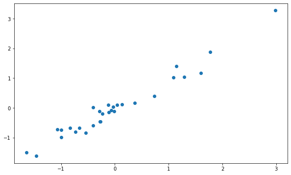

```python
plt.figure(figsize=(10,6))

plt.scatter(normalizedRandomData["x1"], normalizedRandomData["x2"])
```

```python
eigvecs[0,0], eigvecs[1,0]
```

```
(-0.7988578335142531, 0.6015198765069314)
```

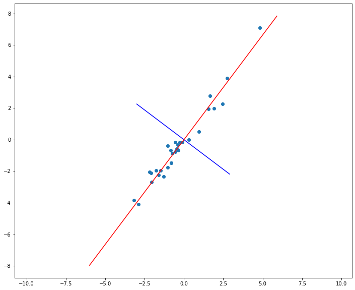

```python
def drawLine2P(x,y, xlims, color):
    xrange = np.arange(xlims[0],xlims[1],0.1)
    A = np.vstack([x, np.ones(len(x))]).T
    k, b = np.linalg.lstsq(A, y)[0]
    plt.plot(xrange, k*xrange + b, color)

plt.figure(figsize=(12,10))
plt.scatter(randomData.x, randomData.y)


drawLine2P((0, eigvecs[0,0]), (0, eigvecs[1,0]), (-3, 3), 'b')
drawLine2P((0, eigvecs[0,1]), (0, eigvecs[1,1]), (-6, 6), 'r')
plt.axis("equal");
```

### Eigenvalues Explain the Variance in the Data

- Eigenvalues explain the variance captured by their Eigenvectors
- We need to transform them into a percentage
  - Dividing each eigenvalue by the sum of eigenvalues.
- Somewhat similar to the $R^2$ discussed in linear regrssion

```python
print("The variance captured by the first  eigenvector is: {}".format(eigvals[0]))

print("The variance captured by the second eigenvector is: {} ".format(eigvals[1]))
```

```
The variance captured by the first  eigenvector is: 0.08637611794470601
The variance captured by the second eigenvector is: 8.464589507431425
```

```python
print("The percentage of variance captured by the first eigenvector is: {}".format(eigvals[0]/ sum(eigvals)))
print("The variance captured by the second eigen vector is: {}".format(eigvals[1]/sum(eigvals)))
```

```
The percentage of variance captured by the first eigenvector is: 0.01010132910467718
The variance captured by the second eigen vector is: 0.9898986708953228
```

### Eigenvalues Explain the Variance in the Data

```python
print("My eigenvectors are :\n %s" % eigvecs)

print("The selected eigenvector is:\n %s" % np.array([[eigvecs[0,1]], [eigvecs[1,1] ]]))
```

```
My eigenvectors are :
 [[-0.79885783 -0.60151988]
 [ 0.60151988 -0.79885783]]
The selected eigenvector is:
 [[-0.60151988]
 [-0.79885783]]
```

```python
newData =  randomData.dot(np.array([[eigvecs[0,1]], [eigvecs[1,1]]]))
newData.columns = ['z']
newData.head()
```

|  | z |
| --- | --- |
| 0 | 4.976950 |
| 1 | 5.012386 |
| 2 | 2.959490 |
| 3 | 2.935565 |
| 4 | 3.390117 |

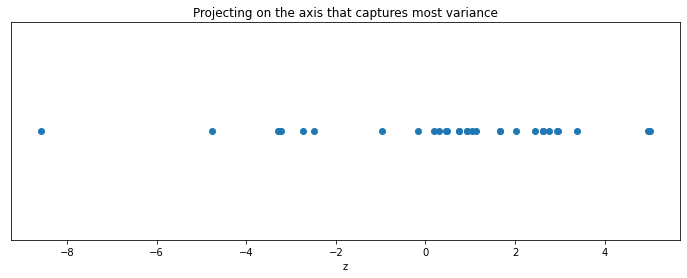

```python
plt.figure(figsize=(12, 4))

plt.xlabel('z')
plt.title('Projecting on the axis that captures most variance')

plt.scatter(newData, [0 for _ in range(len(newData))])
ax = plt.gca()
ax.yaxis.set_visible(False)
```

## Running PCA with Scikit-Learn

- Scikit-Learn has an implementation of PCA similar that described above
  - Scikit-Learn also has many other dimensionality reduction algorithms
- The package finds the eigenvectors and eigenvalues and sort them based on the explained variance ratio

```python
pca = PCA(n_components=2)
_ = pca.fit(randomData)
```

```python
#sns.regplot(x_axis, y_axis, ci=False, fit_reg=False)

pca.explained_variance_ratio_
```

```
array([0.98989867, 0.01010133])
```

```python
pca.components_
```

```
array([[ 0.60151988,  0.79885783],
       [ 0.79885783, -0.60151988]])
```

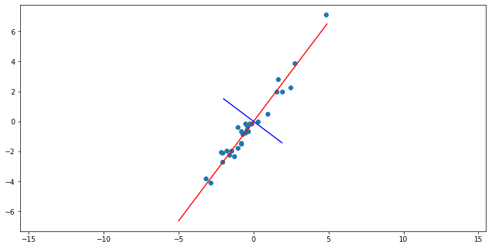

```python
plt.figure(figsize=(12,6))
plt.scatter(randomData.x, randomData.y)

# drawLine2P((0, v[0,0]), (0, v[0,1]), (-6, 6), 'k')

drawLine2P((0, pca.components_[0,0]), (0, pca.components_[1,0]), (-5, 5), 'r')

drawLine2P((0, pca.components_[0,1]), (0, pca.components_[1,1]), (-2, 2), 'b')

plt.axis("equal");
```

```python
print(pca.components_)
```

```
[[ 0.60151988  0.79885783]
 [ 0.79885783 -0.60151988]]
```

```python
print(pca.explained_variance_)
```

```
[8.46458951 0.08637612]
```

```python
print(pca.explained_variance_/sum(pca.explained_variance_))
```

```
[0.98989867 0.01010133]
```

```python
X = randomData.to_numpy()

pca = PCA(n_components=2)

pca.fit(X)
```

```
PCA(n_components=2)
```

[figure not shown]

```python
print("The ration of explained variance is: %s " % pca.explained_variance_ratio_)
```

```
The ration of explained variance is: [0.98989867 0.01010133]
```

### PCA Advantages and Limitations

[figure not shown]

### PCA Limitations

- PCA is unsupervised does not take labels into account.
  - If your data is labeled, PCA cannot take that information into considerations to produce better clusters
  - Method such as LDA or methods based on Correlation Analysis (CA) are used when label data is provided

### Points Crowding Problem

- a major issue when reducing the dimensionality of high-dimensional data is the crowding issue.
  - Somewhat similar points in very high dimension collapsing on top of each other in lower dimensions
  - A lot more space in higher dimensions than lower dimensions, so data can vary in many more ways in higher dimensions yet be very crowded in a lower dimension embedding.

[figure not shown]

### PCA on Very Large Datasets

- PCA assumes that we can store the data, the covariance matrix in RAM.
  - This is often possible with datasets that have a very large number of features.
  - Few GB with a dataset with 15k features
- May not scale for datasets having hundreds of thousands of features.
- Alternative implementations to handle large data
  - Incremental principal component analysis (IPCA) (implemented in scikit-learn)
  - Distributed computation (Implemented in Spark's mllib )
  - Probabilistic approach with theoretical guarantees (ex. ProPCA package)
  - etc...